# Patient Demographics and Outcomes

## Dataset

The dataset is for patients part of the Mt. Sinai Millions (MSM) cohort, for each patient we have some demographic information and their “medical history”. The medical history is the list of ICD codes (specifiyng diagnoses) assigned to a patient by a doctor during a hospital visit for all recorded vists for that patient. So for every visit recorded we have the set of ICD codes assigned. We will turn this long-form medical history into a set of descriptive features for each patient that are better suited to linear modelling where patients are independent data points. We also use the medical history to define the outcome we are studying for each patient and whether they experience SI, Broad SA or Narrow SA.

## Plot Patient Demographics

Load clean demographics data

```r
# all_combined_data <- load_all_combined_data(force_redo=FALSE)
demographics_df <-
    load_demographics_data(force_redo=FALSE)
```

```
0.283 sec elapsed
```

```r
# print rows for investigating
demographics_df %>%
    head() %>%
    kable()
```

| FID | current_age | gender | ethnicity | is_deceased | is_religious | is_cisgender | is_married |
| --- | --- | --- | --- | --- | --- | --- | --- |
| SINAI_69668_AB50932912 | 57 | Male | EAS | Alive | not religious | cisgender | married |
| SINAI_55578_AB49375834 | 45 | Male | AFR | Deceased | religious | cisgender | not married |
| SINAI_184739_1134407361 | 72 | Male | EUR | Alive | not religious | cisgender | married |
| SINAI_30475_AB41948963 | 56 | Female | SAS | Alive | religious | cisgender | married |
| SINAI_27213_AB38973160 | 82 | Female | AFR | Alive | religious | cisgender | not married |
| SINAI_33293_AB43789212 | 73 | Male | EUR | Alive | religious | cisgender | not married |

Plot individual distributions for all 40280 patients with no missing data.

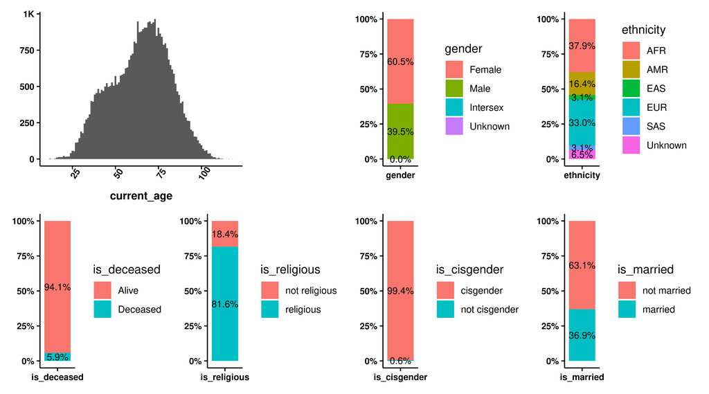

```r
make_single_ggbar <- function(col_name, plot_df=demographics_df){
    plot_df %>%
    select(!!sym(col_name)) %>%
    count(!!sym(col_name)) %>%
    add_column(feature=col_name) %>%  # dummy x-axis
    mutate(pct=prop.table(n)) %>%  # counts to percentages
    arrange(!!sym(col_name)) %>%
    mutate(ypos=1 - (cumsum(pct) - pct/2)) %>%  # percentage label position on figure
    {
        ggplot(
            data=.,
            aes(
                x=feature,
                y=pct,
                fill=.data[[col_name]],
            )
        ) +
        geom_col(position='stack') +  # stacked bar plot
        geom_text(
            aes(
                label=scales::percent(pct, accuracy=0.1),
                y=ypos
            ),
            vjust=0.5,    # nudge above top of bar
            size = 3
        ) +
        scale_y_continuous(labels=scales::percent) +
        guides(fill=guide_legend(ncol=1)) +
        make_ggtheme() +
        theme(
            legend.position='right',
            axis.title=element_blank()
        )
    }
}
current_age_dist <-
    demographics_df %>% select(current_age) %>% add_column(feature='age') %>%
    {
        ggplot(
            aes(x=current_age),
            data=.
        ) +
        geom_histogram(binwidth=1) +
        # coord_flip() +
        scale_y_continuous(labels=label_number(scale_cut=cut_short_scale())) +
        make_ggtheme() +
        theme(
            axis.text.x=element_text(angle=55),
            axis.title.y=element_blank()
        )
    }
# make plot with patchwork
design <- "
CCAB
DEFG
"
{
    make_single_ggbar('gender')       +
    make_single_ggbar('ethnicity')    +
    current_age_dist +
    make_single_ggbar('is_deceased')  +
    make_single_ggbar('is_religious') +
    make_single_ggbar('is_cisgender') +
    make_single_ggbar('is_married')   +
    plot_layout(design=design)
}
```

Plot crosstabs of everything with w/ Gender

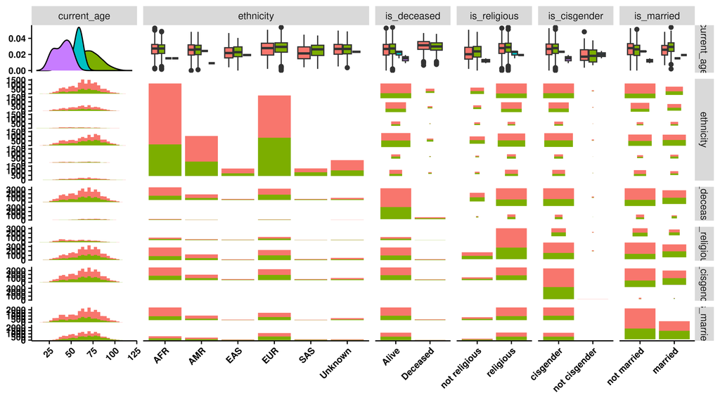

```r
demographics_df %>%
    select(-FID) %>%
    ggpairs(
        binwidth=1,
        columns=setdiff(colnames(demographics_df), c('FID', 'gender')),
        mapping=ggplot2::aes(color=gender),
        proportions='auto',
        upper = list(continuous = wrap(ggally_cor, displayGrid = FALSE))
    ) +
    make_ggtheme() +
    theme(
        axis.text.x=element_text(angle=45, hjust=1, vjust=1)
    )
```

## Defining Patient Outcomes

- Ideation (SI)
- Broad Action (Broad SA)
- Narrow Action (Narrow SA)
- Substance Use Disorder (Substance UD)
- Alcohol Use Disorder (Alcohol UD)

We can further define outcomes based on combinations of SI, BSA and NSA. Each of these combinations excludes some set of samples to make the case/control comparison more clearly interpretable.

The definitions of these “infered” binary outcomes are:

How we defined the “inferred” outcomes

| Outcome Type | Description | Case/Control | SI | Broad_SA | Narrow_SA |
| --- | --- | --- | --- | --- | --- |
| `any_ICD` | any ideation or action | control | [ ] | [ ] | [ ] |
|  |  | case | [x] | [x] | [x] |
| `only_SI` | Only Ideation no action | control | [ ] | [ ] | [ ] |
|  |  | case | [x] | [ ] | [ ] |
| `only_Narrow` | only narrow action | control | [ ] | [ ] | [ ] |
|  |  | case | [ ] | [ ] | [x] |
| `all_ICD` | thoughts and all actions | control | [ ] | [ ] | [ ] |
|  |  | case | [x] | [x] | [x] |
| `only_Action` | No Ideation before action | control | [ ] | [ ] | [ ] |
|  |  | case | [ ] | [x] | [ ] |
|  |  |  | [ ] | [ ] | [x] |
|  |  |  | [ ] | [x] | [ ] |
| `both_SASI` | thoughts and action | control | [ ] | [ ] | [ ] |
|  |  | case | [x] | [x] | [ ] |
|  |  |  | [x] | [ ] | [x] |
|  |  |  | [x] | [x] | [x] |

## Plot Case/Control Frequencies Across Outcomes

Now we can load the outcomes and plot their frequencies against our demogrpahics and our co-morbidities

```r
all_patient_outcomes_df <-
    load_all_patient_outcomes(force_redo=FALSE)
```

```
0.858 sec elapsed
```

```r
all_patient_outcomes_df %>%
    filter(outcome.type == 'SI') %>%
    group_by(case_control_status) %>%
    slice_head(n=4) %>%
    ungroup() %>%
    kable()
```

| FID | outcome.type | earliest_diagnosis | n_codes | n_unique_codes | case_control_status |
| --- | --- | --- | --- | --- | --- |
| SINAI-Million_1105332_2132469751 | SI | NA | NA | NA | control |
| SINAI-Million_193941_3536477784 | SI | NA | NA | NA | control |
| SINAI-Million_P61659021_2132515715 | SI | NA | NA | NA | control |
| SINAI-Million_1038325_2132570634 | SI | NA | NA | NA | control |
| SINAI_73326_AB50297407 | SI | 0.3344853 | 1 | 1 | case |
| SINAI_75833_1094880530 | SI | 0.6640721 | 8 | 1 | case |
| SINAI-Million_1165179_3600843111 | SI | 0.6672414 | 1 | 1 | case |
| SINAI_13520_AB36487809 | SI | 0.7206092 | 1 | 1 | case |

Now we can plot Case/Control frequencies for each outcome

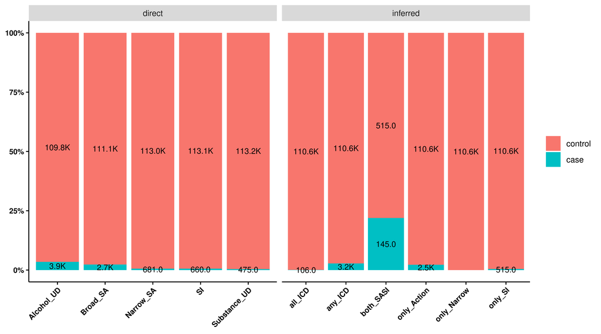

```r
direct_outcomes <- unique(load_ICD_Phenotype_Mappings()$outcome.type)
# all_patient_outcomes_df
all_patient_outcomes_df %>%
    select(FID, outcome.type, case_control_status) %>%
    mutate(outcome.definition=ifelse(outcome.type %in% direct_outcomes, 'direct', 'inferred')) %>%
    group_by(
        outcome.definition,
        outcome.type,
        case_control_status
    ) %>%
    summarize(n=n()) %>%
    mutate(pct=prop.table(n)) %>%  # counts to percentages
    mutate(ypos=1 - (cumsum(pct) - pct/2)) %>%  # percentage label position on figure
    {
        ggplot(
            data=.,
            mapping=
                aes(
                    x=outcome.type,
                    y=pct
                )
        ) +
        geom_col(aes(fill=case_control_status), position='stack') +  # stacked bar plot
        geom_text(
            aes(
                y=ypos,
                label=
                    scales::number(
                        n,
                        accuracy=0.1,
                        scale_cut=scales::cut_short_scale()
                    ),
            ),
            vjust=0.5,    # nudge above top of bar
            size = 3
        ) +
        facet_grid(
            cols=vars(outcome.definition),
            # rows=vars(metric),
            scales='free'
        ) +
        scale_y_continuous(labels=scales::percent) +
        make_ggtheme() +
        theme(
            axis.text.x=element_text(angle=45, hjust=1, vjust=1),
            axis.title=element_blank(),
            legend.title=element_blank()
        )
    }
```

For those direct outcome cases, we can also plot those extra datapoints to see how our cases vary

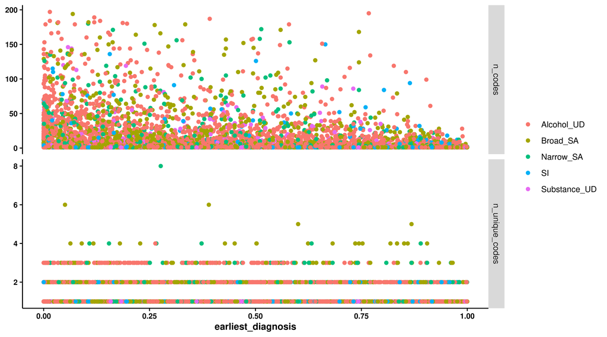

```r
all_patient_outcomes_df %>%
    filter(outcome.type %in% direct_outcomes) %>%
    filter(case_control_status == 'case') %>%
    filter(n_codes < 200) %>%  # wierd outliers
    pivot_longer(starts_with('n_'), names_to='metric', values_to='value') %>%
    {
        ggplot(
            data=.,
            mapping=
                aes(
                    x=earliest_diagnosis,
                    y=value,
                    color=outcome.type
                )
        ) +
        geom_point() +
        # geom_smooth(method='lm') +
        facet_grid(
            rows=vars(metric),
            scales='free_y'
        ) +
        make_ggtheme() +
        theme(
            # axis.text.x=element_text(angle=45, hjust=0.5, vjust=0.5),
            axis.title.y=element_blank(),
            legend.title=element_blank()
        )
    }
```